# Lektion 1

### Auswahl von Elementen

Die Indizierung von `DataFrame` Objekten ist sehr viellseitig und eine komplete Ausführung würde hier den Rahmen sprengen. Wir verweisen dafür auf Kapitel 3 im Buch von Jake VanderPlas *Python für Data Science*. Hier seien die grundlegenden Verfahren beschrieben. Die Indizierung kann analog zu einem `Numpy`-Array erfolgen. Hier ist zu beachten, dass der letzte Index *nicht* mehr ausgegeben wird, wie folgendes Beispiel eines *slices* zeigt:

```python
GM[20:24]
```

|  | Country | Year | fertility | life | population | child_mortality | gdp | region |
| --- | --- | --- | --- | --- | --- | --- | --- | --- |
| 20 | Afghanistan | 1984 | 7.676 | 43.661 | 12931791.0 | 222.9 | 1429.0 | South Asia |
| 21 | Afghanistan | 1985 | 7.679 | 44.400 | 12625292.0 | 216.0 | 1384.0 | South Asia |
| 22 | Afghanistan | 1986 | 7.681 | 45.192 | 12372113.0 | 209.2 | 1486.0 | South Asia |
| 23 | Afghanistan | 1987 | 7.682 | 46.024 | 12183387.0 | 202.1 | 1230.0 | South Asia |

Der `DataFrame` im obigen Beispiel hat eine etwas eigentümliche Struktur im Sinne des Maschinellen Lernens. Die Ausprägungen des Merkmals `Country` sind streckenweise konstant, wobei jeweils Werte in verschiedenen Jahren angegeben werden. Rein formal entspricht der Datensatz so der gewünschten Form von *tidy data*, aber eigentlich sind `Country` und `Year` keine Merkmale, sondern *Indizes*.

Wir machen dies deutlich, in dem wir zunächst die Daten eines Jahres auswählen. Dies kann einerseits über *logische* Bedingungen erfolgen.

```python
GM_1980 = GM[GM['Year']==1980]
GM_1980.head()
```

|  | Country | Year | fertility | life | population | child_mortality | gdp | region |
| --- | --- | --- | --- | --- | --- | --- | --- | --- |
| 16 | Afghanistan | 1980 | 7.669 | 41.242 | 14185729.0 | 249.10 | 1158.0 | South Asia |
| 66 | Albania | 1980 | 3.678 | 70.218 | 2671300.0 | 78.60 | 4218.0 | Europe & Central Asia |
| 116 | Algeria | 1980 | 6.889 | 58.198 | 18811199.0 | 148.00 | 10166.0 | Middle East & North Africa |
| 166 | Angola | 1980 | 7.200 | 40.182 | 7638420.0 | 234.10 | 4443.0 | Sub-Saharan Africa |
| 216 | Antigua and Barbuda | 1980 | 2.115 | 68.873 | 70228.0 | 37.53 | 8169.0 | America |

Klarerweise ist jetzt das Merkmal `Year` überflüssig. Wir entfernen die Spalte mit `drop`

```python
GM_1980 = GM_1980.drop('Year', axis=1)
GM_1980.describe()
```

|  | fertility | life | population | child_mortality | gdp |
| --- | --- | --- | --- | --- | --- |
| count | 202.000000 | 202.000000 | 2.020000e+02 | 189.000000 | 180.000000 |
| mean | 4.520273 | 62.060974 | 2.204167e+07 | 95.089577 | 12796.061111 |
| std | 2.059417 | 10.488236 | 8.793888e+07 | 80.586959 | 21997.774776 |
| min | 1.454000 | 26.000000 | 5.020800e+04 | 8.500000 | 499.000000 |
| 25% | 2.386250 | 54.460250 | 7.912948e+05 | 28.700000 | 2231.000000 |
| 50% | 4.691000 | 65.322000 | 4.118194e+06 | 66.400000 | 6308.000000 |
| 75% | 6.438750 | 70.326500 | 1.347318e+07 | 155.200000 | 15926.250000 |
| max | 8.993000 | 76.660000 | 9.831706e+08 | 330.930000 | 182668.000000 |

Der Name des Landes ist eher ein Index als ein Merkmal (technisch gesehen ist der Name `Afghanistan` ein Merkmal des Landes Afghanistan, aber es beinhaltet keine statistisch relevante Information). Wir setzen also den Index auf den Namen des Landes (wir gehen davon aus, dass der Name eindeutig ist, d.h. das es nicht zwei unterschiedliche Länder mit dem Namen Afghanistan gibt o.ä.)

```python
GM_1980.set_index('Country', inplace=True, drop=True)
GM_1980.head()
```

| Country | fertility | life | population | child_mortality | gdp | region |
| --- | --- | --- | --- | --- | --- | --- |
| Afghanistan | 7.669 | 41.242 | 14185729.0 | 249.10 | 1158.0 | South Asia |
| Albania | 3.678 | 70.218 | 2671300.0 | 78.60 | 4218.0 | Europe & Central Asia |
| Algeria | 6.889 | 58.198 | 18811199.0 | 148.00 | 10166.0 | Middle East & North Africa |
| Angola | 7.200 | 40.182 | 7638420.0 | 234.10 | 4443.0 | Sub-Saharan Africa |
| Antigua and Barbuda | 2.115 | 68.873 | 70228.0 | 37.53 | 8169.0 | America |

Das sieht doch schon einmal besser aus! Das selbe Resultat hätten wir auch mit dem mächtigen `groupby`-Befehl erreicht. Er gruppiert den Datensatz nach den Werten eines Merkmals. Mit dem Befehl `get_group` kann denn jede gewünschte Gruppe extrahiert werden.

```python
GM_1980_v1 = GM.groupby('Year').get_group(1980)
GM_1980 = GM_1980_v1.drop('Year', axis=1).set_index('Country', drop=True)
GM_1980.head()
```

| Country | fertility | life | population | child_mortality | gdp | region |
| --- | --- | --- | --- | --- | --- | --- |
| Afghanistan | 7.669 | 41.242 | 14185729.0 | 249.10 | 1158.0 | South Asia |
| Albania | 3.678 | 70.218 | 2671300.0 | 78.60 | 4218.0 | Europe & Central Asia |
| Algeria | 6.889 | 58.198 | 18811199.0 | 148.00 | 10166.0 | Middle East & North Africa |
| Angola | 7.200 | 40.182 | 7638420.0 | 234.10 | 4443.0 | Sub-Saharan Africa |
| Antigua and Barbuda | 2.115 | 68.873 | 70228.0 | 37.53 | 8169.0 | America |

Auf die gruppierten Variabeln können jetzt z.B. statistisch Merkmale angewendet werden. Wir führen dies am Beispiel des Mittelwerts vor. Wir gruppieren den Datensatz `GM_1980` nach dem Kontinent (`region`) und berechnen den Mittelwert in den Gruppen.

```python
GM_1980.groupby('region').mean()
```

| region | fertility | life | population | child_mortality | gdp |
| --- | --- | --- | --- | --- | --- |
| America | 3.817075 | 66.642225 | 1.541232e+07 | 60.675278 | 10507.156250 |
| East Asia & Pacific | 4.096585 | 62.745599 | 4.876455e+07 | 73.524643 | 11875.576923 |
| Europe & Central Asia | 2.382813 | 70.556464 | 1.555111e+07 | 37.085208 | 16360.750000 |
| Middle East & North Africa | 6.260905 | 62.244190 | 8.896094e+06 | 87.467000 | 37731.526316 |
| South Asia | 6.003875 | 52.826250 | 1.132596e+08 | 173.937500 | 1533.625000 |
| Sub-Saharan Africa | 6.565760 | 50.693020 | 7.789134e+06 | 179.755102 | 3059.851064 |

Mit dem Datensatz können nun erste Visualisierungen durchgeführt werden, wobei wir in der nächsten Lektion diese wichtige Werkzeug der Datenanalyse vertieft kennen lernen werden. Hier beginnen wir mit einem `Scatter-Plot`, den wir mit dem Paket `seaborn` erzeugen (dazu später mehr).

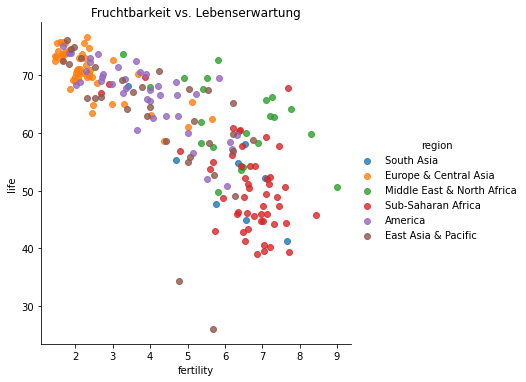

```python
import matplotlib.pyplot as plt
import seaborn as sns

sns.lmplot("fertility", "life", hue="region", data = GM_1980, fit_reg=False)
plt.title("Fruchtbarkeit vs. Lebenserwartung")
plt.show()
```

```python
df=GM.groupby('Country').mean()
df.head(10)
df=df.sort_values('child_mortality')
df.head()
```

| Country | Year | fertility | life | population | child_mortality | gdp |
| --- | --- | --- | --- | --- | --- | --- |
| Hong Kong- China | 1988.5 | 1.87784 | 77.07210 | 5.589137e+06 | 6.565588 | 25419.82 |
| Sweden | 1988.5 | 1.85000 | 77.63938 | 8.566942e+06 | 7.570000 | 30627.08 |
| Iceland | 1988.5 | 2.38760 | 77.83048 | 2.533287e+05 | 8.274000 | 27422.86 |
| Finland | 1988.5 | 1.80606 | 75.09232 | 4.961606e+06 | 8.380000 | 26718.08 |
| Japan | 1988.5 | 1.64512 | 78.04134 | 1.179167e+08 | 9.144000 | 24666.10 |

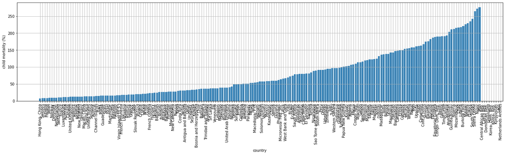

```python
import matplotlib.pyplot as plt
%matplotlib inline

plt.figure(figsize=(24,5))
plt.bar(df.index,df.iloc[:,4],label='child_mortality')
plt.grid(True)
plt.xlabel('country')
plt.xticks(rotation='vertical')
plt.ylabel('child mortality (%)')
```

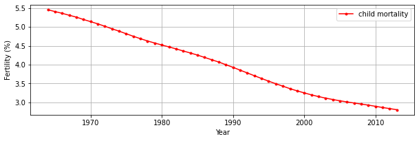

```python
df=GM.groupby('Year').mean()

plt.figure(figsize=(10,10))
ax = plt.subplot(311)
plt.plot(df.iloc[:,0],'r.-',label='child mortality')
ax.grid(True)
ax.set_xlabel('Year')
ax.set_ylabel('Fertility (%)')
ax.legend()
```

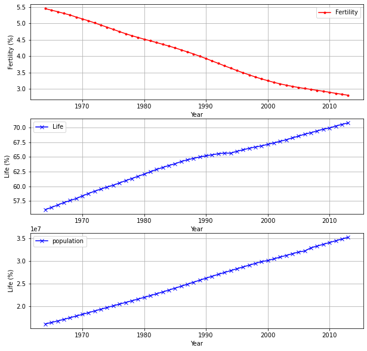

```python
plt.figure(figsize=(10,10))
ax = plt.subplot(311)
plt.plot(df.iloc[:,0],'r.-',label='Fertility')
ax.grid(True)
ax.set_xlabel('Year')
ax.set_ylabel('Fertility (%)')
ax.legend()

ax = plt.subplot(312)
plt.plot(df.iloc[:,1],'bx-',label='Life')
ax.grid(True)
ax.set_xlabel('Year')
ax.set_ylabel('Life (%)')
ax.legend()

ax = plt.subplot(313)
plt.plot(df.iloc[:,2],'bx-',label='population')
ax.grid(True)
ax.set_xlabel('Year')
ax.set_ylabel('Life (%)')
ax.legend()
```

```python
df=GM.pivot(index='Country', columns='Year',values = 'life')
df.head()
```

| Year Country | 1964 | 1965 | 1966 | 1967 | 1968 | 1969 | 1970 | 1971 | 1972 | 1973 | ... | 2004 | 2005 | 2006 | 2007 | 2008 | 2009 | 2010 | 2011 | 2012 | 2013 |
| --- | --- | --- | --- | --- | --- | --- | --- | --- | --- | --- | --- | --- | --- | --- | --- | --- | --- | --- | --- | --- | --- |
| Afghanistan | 33.639 | 34.152 | 34.662 | 35.170 | 35.674 | 36.172 | 36.663 | 37.143 | 37.614 | 38.075 | ... | 56.583 | 57.071 | 57.582 | 58.102 | 58.618 | 59.124 | 59.612 | 60.079 | 60.524 | 60.947 |
| Albania | 65.475 | 65.863 | 66.122 | 66.316 | 66.500 | 66.702 | 66.948 | 67.251 | 67.595 | 67.966 | ... | 75.725 | 75.949 | 76.124 | 76.278 | 76.433 | 76.598 | 76.780 | 76.979 | 77.185 | 77.392 |
| Algeria | 47.953 | 48.389 | 48.806 | 49.205 | 49.592 | 49.976 | 50.366 | 50.767 | 51.195 | 51.670 | ... | 69.682 | 69.854 | 70.020 | 70.180 | 70.332 | 70.477 | 70.615 | 70.747 | 70.874 | 71.000 |
| Angola | 34.604 | 35.007 | 35.410 | 35.816 | 36.222 | 36.627 | 37.032 | 37.439 | 37.846 | 38.247 | ... | 48.036 | 48.572 | 49.041 | 49.471 | 49.882 | 50.286 | 50.689 | 51.094 | 51.498 | 51.899 |
| Antigua and Barbuda | 63.775 | 64.149 | 64.511 | 64.865 | 65.213 | 65.558 | 65.898 | 66.232 | 66.558 | 66.875 | ... | 74.355 | 74.544 | 74.729 | 74.910 | 75.087 | 75.263 | 75.437 | 75.610 | 75.783 | 75.954 |

5 rows × 50 columns

```python
df.tail()
```

| Year Country | 1964 | 1965 | 1966 | 1967 | 1968 | 1969 | 1970 | 1971 | 1972 | 1973 | ... | 2004 | 2005 | 2006 | 2007 | 2008 | 2009 | 2010 | 2011 | 2012 | 2013 |
| --- | --- | --- | --- | --- | --- | --- | --- | --- | --- | --- | --- | --- | --- | --- | --- | --- | --- | --- | --- | --- | --- |
| Western Sahara | 39.880 | 40.256 | 40.619 | 40.969 | 41.316 | 41.674 | 42.067 | 42.524 | 43.066 | 43.700 | ... | 64.583 | 65.008 | 65.409 | 65.790 | 66.155 | 66.507 | 66.844 | 67.167 | 67.473 | 67.764 |
| Yemen- Rep. | 36.068 | 36.957 | 37.827 | 38.679 | 39.516 | 40.346 | 41.176 | 42.017 | 42.878 | 43.763 | ... | 61.307 | 61.520 | 61.728 | 61.933 | 62.136 | 62.337 | 62.536 | 62.731 | 62.923 | 63.112 |
| Zambia | 46.574 | 46.929 | 47.303 | 47.704 | 48.131 | 48.580 | 49.044 | 49.513 | 49.970 | 50.392 | ... | 45.791 | 47.156 | 48.613 | 50.126 | 51.648 | 53.137 | 54.549 | 55.851 | 57.037 | 58.105 |
| Zimbabwe | 52.993 | 53.325 | 53.648 | 53.965 | 54.279 | 54.596 | 54.918 | 55.247 | 55.586 | 55.940 | ... | 43.244 | 43.958 | 45.157 | 46.827 | 48.890 | 51.234 | 53.684 | 56.040 | 58.142 | 59.871 |
| Åland | NaN | NaN | NaN | NaN | NaN | NaN | NaN | NaN | NaN | NaN | ... | 79.880 | 80.000 | 80.100 | NaN | NaN | NaN | NaN | NaN | NaN | NaN |

5 rows × 50 columns